# Doing Reproducible Work with SAS and JupyterLab

[figure not shown]

## SAS Global Forum 2019 Tutorial Session 4033

## Daymond Ling

- Professor, School of Marketing, Seneca College
- Head of Analytics, Questrade Financial Group

## Learning Outcome

You will learn the following:

- Become familiar with JupyterLab UI and functionalities
- Edit and execute SAS Code cells
- Create and render Markdown cells
- Export notebook in a variety of formats
- How to install JupyterLab, SAS_kernel and SASpy

## Material

This tutorial, the interactive demo, the slideshow, the handouts were built using the JupyterLab ecosystem:

- Notebook is built with JupyterLab with ToC extension
- Slideshow is built with JupyterLab and nbconvert
- HTML file is built with JupyterLab and nbconvert
- PDF is built with JupyterLab and nbconvert

# JupyterLab

You spent days and weeks doing Data Science in SAS using SAS Studio, SAS Enterprise Guide or SAS Display Manager. It is done now, you want to share your analytic process and results for publication. You start up a writing tool, perhaps Microsoft Word or PowerPoint or Latex, and as you write your thoughts and copy/paste large quantities of code, tables and graphs, you say to yourself, this is awkward, there’s got to be a better way.

And there is. This problem is not new, the scientific community has wrestled with this dilemma for a long time. One open source software solution is **[JupyterLab](https://github.com/jupyterlab/jupyterlab)** from **[Project Jupyter](https://jupyter.org/)**. JupyterLab is the digital version of a scientist’s lab notebook that ties text, code and outputs together in one document. It is a live computational notebook in that the code in the notebook can be executed directly to reproduce and verify results, something static documents cannot do.

JupyterLab supports many **[language kernels](https://github.com/jupyter/jupyter/wiki/Jupyter-kernels)**. SAS contributed the **sas_kernel** which lets you run SAS directly in a notebook, and **saspy** which let's you access SAS as a package in a Python notebook. **[SAS University Edition](https://www.sas.com/en_ca/software/university-edition.html)** now comes bundled with JupyterLab in addition to SAS Studio.

## History

The **[Python](https://www.python.org/)** language (version 0.9, 1991; version 1.0, 1994; version 2, 2000, version 3, 2008) comes with a bare bones command line interface. IPython was conceived in 2001 as an enhanced, rich REPL for working with Python 2. It then matured from a command line REPL into a browser based interface that captures text, code and output in a notebook - the **ipython notebook** with the file extension of **.ipynb**.

Project Jupyter was spun off from IPython in 2014 to support multiple languages, its name is in recognition of the main open source scientific languages at that time of **[Julia](https://julialang.org/)**, **[Python](https://www.python.org/)**, and **[R](https://cran.r-project.org/)**, notebooks thus became **jupyter notebook** instead of ipython notebook.

JupyterLab is the next evolution of Jupyter Notebook with a re-architected interface that provides much more functionality than Jupyter Notebook. In Feb 2018, the development team said it is [good enough for daily use](https://blog.jupyter.org/jupyterlab-is-ready-for-users-5a6f039b8906), technically it is not out of beta yet, but is expected to reach version 1.0 soon (was supposed to be late 2018).

# SAS & JupyterLab Live Demo

# Notebook

A notebook is a linear sequential flow of **cells**, there is no notion of a page. There are three types of cells:

| Cell type | Content | Shift+Enter |
| --- | --- | --- |
| Code | Code for the language kernel | Execution, output display |
| Markdown | Markdown text | Formatted view |
| Raw | raw text | Nothing |

When you open a notebook, JupyterLab starts up the kernel for the notebook. Each notebook has its own associated kernel session.

## Code Cell

Code cells contain code statements, **Shift+Enter** runs the cell.  
When executed the cell is tagged with the **run sequence number** of this session. This way you can check whether cells are executed in sequence or not.

## Cell Output

When executed, cell output appear below the code. SAS program generates Log messages and possibly Results. Cell Output displays:

- if there are no Results, Log is displayed
- if there are Results, it is displayed and Logs are suppressed unless there are ERROR messages, then it is displayed ahead of Results.

This usually leads to a clean notebook.

```sas
title;   ods noproctitle;
proc print data=sashelp.fish(obs=5); run;
```

```
SAS Connection established. Subprocess id is 14152
```

| Obs | Species | Weight | Length1 | Length2 | Length3 | Height | Width |
| --- | --- | --- | --- | --- | --- | --- | --- |
| 1 | Bream | 242 | 23.2 | 25.4 | 30.0 | 11.5200 | 4.0200 |
| 2 | Bream | 290 | 24.0 | 26.3 | 31.2 | 12.4800 | 4.3056 |
| 3 | Bream | 340 | 23.9 | 26.5 | 31.1 | 12.3778 | 4.6961 |
| 4 | Bream | 363 | 26.3 | 29.0 | 33.5 | 12.7300 | 4.4555 |
| 5 | Bream | 430 | 26.5 | 29.0 | 34.0 | 12.4440 | 5.1340 |

Dependent Variable: Weight

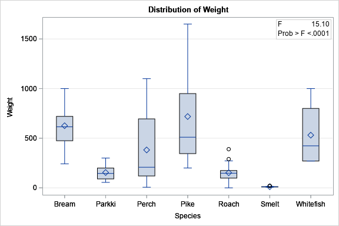

```sas
ods graphics / width=6in height=4in;
proc glm data=sashelp.fish;
    ods select BoxPlot;
    class species;
    model weight = species;
run; quit;
```

```sas
data fish;
    set sashelp.fish;
    file print linesize=30;
    put _n_= weight=;
    if _n_ >= 5 then stop;
    drop xxx;                   * this stmt causes warning;
run;
```

```
_N_=1 Weight=242
_N_=2 Weight=290
_N_=3 Weight=340
_N_=4 Weight=363
_N_=5 Weight=430
```

```sas
%showLog
```

```
6                                                                                                                        The SAS System                                                                                       18:36 Wednesday, February 27, 2019

50         ods listing close;ods html5 (id=saspy_internal) file=_tomods1 options(bitmap_mode='inline') device=svg style=HTMLBlue; ods graphics on / outputfmt=png;
NOTE: Writing HTML5(SASPY_INTERNAL) Body file: _TOMODS1
51

NOTE: PROCEDURE GLM used (Total process time):
      real time           19.02 seconds
      cpu time            0.46 seconds


52         data fish;                      * Result suppresses Log with WARNING messages;
53             set sashelp.fish;
54             file print linesize=30;
55             put _n_= weight=;
56             if _n_ >= 5 then stop;
57             drop xxx;
58         run;

WARNING: The variable xxx in the DROP, KEEP, or RENAME list has never been referenced.
NOTE: Non-portable document will be produced. The current settings of FORMCHAR use nonstandard line-drawing characters and the resulting output file will not render correctly unless all readers of the document have the SAS Monospace font installed. To
      make your document portable, issue the following command:
      OPTIONS FORMCHAR="|----|+|---+=|-/\<>*";

NOTE: 5 lines were written to file PRINT.
NOTE: There were 5 observations read from the data set SASHELP.FISH.
NOTE: The data set WORK.FISH has 4 observations and 7 variables.
NOTE: DATA statement used (Total process time):
      real time           0.17 seconds
      cpu time            0.01 seconds


59
60         ods html5 (id=saspy_internal) close;ods listing;
61
```

```sas
proc print data=sashelp.fish(keep=xxx);     run;    * causes ERROR;
proc print data=sashelp.fish(obs=1);    run;
```

```
7                                                                                                                        The SAS System                                                                                       18:36 Wednesday, February 27, 2019

64         ods listing close;ods html5 (id=saspy_internal) file=_tomods1 options(bitmap_mode='inline') device=svg style=HTMLBlue; ods graphics on / outputfmt=png;
NOTE: Writing HTML5(SASPY_INTERNAL) Body file: _TOMODS1
65
66         proc print data=sashelp.fish(keep=xxx);     run;
ERROR: The variable xxx in the DROP, KEEP, or RENAME list has never been referenced.

NOTE: The SAS System stopped processing this step because of errors.
NOTE: PROCEDURE PRINT used (Total process time):
      real time           0.11 seconds
      cpu time            0.01 seconds

66       !                                                     * Result and Log ERROR show both;


67         proc print data=sashelp.fish(obs=1);    run;

NOTE: There were 1 observations read from the data set SASHELP.FISH.
NOTE: PROCEDURE PRINT used (Total process time):
      real time           0.04 seconds
      cpu time            0.03 seconds


68
69         ods html5 (id=saspy_internal) close;ods listing;
70
```

| Obs | Species | Weight | Length1 | Length2 | Length3 | Height | Width |
| --- | --- | --- | --- | --- | --- | --- | --- |
| 1 | Bream | 242 | 23.2 | 25.4 | 30 | 11.52 | 4.02 |

# Markdown

Markdown cell contain plain text with **[special formatting codes](https://github.com/adam-p/markdown-here/wiki/Markdown-Cheatsheet)**.

Paragraphs are separated by a line ending with **two enter keys**. Sentences in the same paragraph flow together. Each of the sentences in this paragraph are on a separate line, but they flow together when rendered. This last line ends with two enters terminating this paragraph.

This is another paragraph. Within a paragraph you can goto a newline a line by ending a line with **two spaces**. This line ends with two spaces.  
This is the following line, it is not flowed with the preceding line and starts on a new line.

# A single # is Heading 1

## Two ## is Heading 2

### Three ### is Heading 3

#### Four #### is Heading 4

##### Five ##### is Heading 5

###### Six ###### is Heading 6

## Emphasis

| Code | Effect |
| --- | --- |
| *italics* | *italics* |
| **bold** | **bold** |
| ~~text~~ | text |
| [text](url) | displays text as a clickable link to URL |
| ![alttext](img/SGF2019.png) | embeds image, path can be local path or URL address of an image |

## Lists

Numbered list: initial number is start, following is auto increment

```
2. item 1, the 2 controls starting list number
1. item 2, the numbers designate next item, the number is ignored
1. item 3
```

1. item 1
2. item 2
3. item 3

Bullet list:

```
- bullet 1
- bullet 2
- bullet 3
```

- bullet 1
- bullet 2
- bullet 3

They can be nested via indentation.

## Tables

Tables use | to separate text into columns. The first line is the heading, the second line must be dashes, each following line is a row of the table. You don't need to align the columns, just type in the content.

```
Cell type | Content | Shift+Enter
----------|---------|-------------
Code | Code for the language kernel | Execution, output display
Markdown | Markdown text | Formatted view
Raw | raw text | Nothing
```

gives

| Cell type | Content | Shift+Enter |
| --- | --- | --- |
| Code | Code for the language kernel | Execution, output display |
| Markdown | Markdown text | Formatted view |
| Raw | raw text | Nothing |

## Math

You can show mathematical equations with Mathjax inline $E = mc^2$ or on its own line

$$E = mc^2$$$$\sum_{i=0}^n i^2 = \frac{(n^2+n)(2n+1)}{6}$$$$\left\{q\in {Q'} \middle| P(q)\right\}$$\begin{array}{c|lcr} n & \text{Left} & \text{Center} & \text{Right} \\ \hline 1 & 0.24 & 1 & 125 \\ 2 & -1 & 189 & -8 \\ 3 & -20 & 200 & 1+10i \end{array}

# Slides

You can create a slideshow directly from your notebook, this is great for technical presentations. PowerPoint/Google Slides/Prezi falls short in this arena as they require a lot of copy/paste/resize.

The slides are organized in a two dimensional structure, not linearly:

- Slides for the same topic are arranged vertically within a column
- Multiple topics are laid out sideways in separate columns

You attach metadata to each cell for Slide purposes using the Cell Inspector wrench on the left as follows:

| Types | Usage |
| --- | --- |
| Slide | start a new column, navigate across columns with left/right arrows |
| Sub-Slide | add to current column, navigate with up/down arrows, left/right moves across columns |
| Fragment | vertical animation - current cell is added to bottom of previous slide |
| Skip, Notes | These cells are explicitly ignored, they don't appear in the Slideshow |
| N/A | Cells without any metadata are also ignored |

## Generating Slideshow

After tagging your cells, the slideshow is prepared with **File > Export Notebook As... > Export Notebook to Reveal.js Slides**.

Or you can use this command:

```
jupyter nbconvert notebook.ipynb --to slides --post serve
```

`--to slides` tell Jupyter to create a **notebook.slides.html** file, `--post serve` opens it in a browser.

You can do it as two separate steps if you want:

```
jupyter nbconvert notebook.ipynb --to slides
start notebook.slides.html
```

Note: there are no warning messages for long slides that don't fit the screen. You should check your presentation slides and split cells as necessary.

Also pay attention to embedded local links (relative path, absolute path, sharing with others...).

## Slideshow Navigation

When the slideshow is displayed:

- navigation hints at the bottom right hand corner shows allowed movement directions
- there is a thin horizontal progress bar at the top showing position in slideshow
- you can get a bird's eye view of the 2-D layout at any time with the **Esc** key

You can share the notebook.slides.html slideshow file, no other software is required to view it besides a browser.

# Other Output Formats

You can export the notebook in a variety of formats, **File > Export Notebook As...**

1. **HTML** exports the notebook as a single .html file. Like the notebook, HTML has no concept of pages, it is one long document without page breaks. Wide tables are scrollable. This is a good way to capture a snapshot of the live notebook. Be careful of local links.
2. When viewing the HTML file in a browser, use **Print... > Save as PDF** to quickly convert to a useable PDF document with some minor pagination blemishes.
3. **PDF** is a standard page oriented document format. When exported as a PDF, the notebook may not paginate in a pleasant manner, SAS output doesn't show, trying to beautify the PDF document is painful even when you know Latex. Avoid this approach.

These export functions rely upon **nbconvert**.

# Reproducibility

There are (at least) three ways where the visual appearance of a notebook may not represent the true state of affairs:

1. JupyterLab automatically numbers code cells by the **execution order** in this session of the notebook. By looking at the numbers you can tell whether the code cells were executed in sequence or not.
2. After you run a code cell, you can edit the code without executing it causing code and output to be out of sync. There is no visual clue of code alteration after execution.
3. The software environment is different, this is beyond JupyterLab. With SAS this is not (or less of) an issue because SAS is compatible across versions. However, it is a big issue with open source language and packages ecosystem due to its unorchestrated continuous evolution.

#1 and #2 can be mitigated by

1. Take a snapshot with **File > Export Notebook As... > Export Notebook to HTML**
2. Execute the entire notebook with **Kernel > Restart Kernel and Run All Cells...** and compare

## Not an IDE

JuputerLab and IDE (Integrated Development Environment) serve different purposes. It is important to appreciate what each is built to address.

| Functionality | JupyterLab - Idea Centric, Communicate, Demonstrate, Share | IDE - Code Centric, Build, Test, Manage |
| --- | --- | --- |
| Purpose | Great for exposition, exploration, and demonstration of an idea. Complex projects would use many notebooks. | Used for large scale software development of many code modules, not designed for intermingling of code/output and text. |
| Reproducibility | Meant to share ideas, code and results in a reproducible manner amongst people | Manage large scale code development, not built to discuss idea or share output |
| Environment | Web Browser | Custom interface |
| Save | Notebook in json format | Code in text files |
| Version Control | Can't do version control of a notebook | Code modules can be put under version control |
| Code | Usually only a few lines in each cell, unusual to have hundreds of lines in a single cell | Can have very large code packages and modules |
| Editor | Edits within a single notebook relying on browser for search/replace | Sophisticated search/replace across multiple modules using regular expressions |
| Snippet | What? | Code snippet templates |
| Diff | What? | Sophisticated side-by-side file comparison |
| Debugger | What? | Debugger to step through execution and into functions, set break points |
| Workspace | What? | Can view workspace variables and their values |
| FTP-edit | What? | Can edit files on remote machines via SSH/FTP transparently |
| Unit test | What? | Run cases to stress test the software module |
| Math equations | Render via Mathjax | What? |
| Code output | Appears below code cell | What? |
| Publish | Convert notebook to HTML, PDF, Latex,... | What? |
| Slideshow | Convert notebook to slideshow | What? |

## No Defense against Abuse

Joel Grus **[I don't like Notebooks](https://www.youtube.com/watch?v=7jiPeIFXb6U)** (**[slides](https://conferences.oreilly.com/jupyter/jup-ny/public/schedule/detail/68282)**)  
YiHui Xie (RMarkdown creator) **[The First Notebook War](https://yihui.name/en/2018/09/notebook-war/)**

Like any tool, notebooks can be used to great effect or it can be totally butchered.  
Don't blame the tool, blame the user.  
Notebook will not turn a bad programmer into a good one.  
Bad habits are bad habits, it will show up regardless of what tool they use.

Use a notebook to discuss/share a single simple idea, do not use it for software development.  
Use a notebook when you are doing data analysis, do not use it when you are writing a data analysis package for others to use.  
Use a notebook when you are soving problems and need to use code, do not use it when you want to create software tools.

# JupyterLab Installation

**[SAS University Edition](https://www.sas.com/en_ca/software/university-edition.html)** comes bundled with JupyterLab. If you are using SAS UE, you are ready to go.  
Note that SAS UE is a packaged application that runs in a virtual machine on your computer, you cannot alter the environment, e.g., add your own packages.

If you have access to SAS locally or remotely, you can install JupyterLab to access it.

- Being open source, you can find the source code for **[JupyterLab on GitHub](https://github.com/jupyterlab/jupyterlab/)**
- Documentation is at **[Read the Docs](https://jupyterlab.readthedocs.io/en/latest/)**

The instructions below use Python's **pip** command, not Anaconda or Miniconda. They are current as of March, 2019.

### Install Python 3

1. Download **[Python](https://www.python.org/)**
2. Install it at some directory, let's call it *pydir*, add Python to system **PATH**

Check that *pydir* and *pydir/Scripts* are on system **PATH**.

### Install JupyterLab

From the command prompt or terminal window:

```
pip install jupyterlab
```

### Update JupyterLab

From the command prompt or terminal window:

```
pip install --upgrade jupyterlab
```

### Running JupyterLab

From the command prompt or terminal window:

```
jupyter lab        # jupyter-lab works as well
```

JupyterLab will open in your default browser, current versions of Chrome or Firefox are fine, Internet Explorer will not work.

You should create a shortcut to JupyterLab and edit Properties to choose the directory to start in, all notebooks will be created under this location.

The Launcher tab shows the list of available kernels, Python is automatically available.

### Other pip commands

- `pip list` lists installed packages
- `pip install pkg==` lists all available versions of that pkg
- `pip install pkg==a.b.c` installs version a.b.c of pkg
- `pip install --upgrade pkg1 pkg2 ...` upgrades listed packages to most current version
- `pip uninstall pkg1 pkg2 ...` uninstalls the listed packages

## Useful JupyterLab Extensions

You can find a list of **[JupyterLab extensions](https://github.com/topics/jupyterlab-extension)** on GitHub.

1. Download and install **[node.js](https://nodejs.org/)**
   - if you have admin rights, use the installer
   - if you have a user account, use the zip file
2. From command prompt: `jupyter labextension install @jupyterlab/toc`

### Controlling JupyterLab Extensions

- `jupyter labextension list`
- `jupyter labextension install ext-name`
- `jupyter labextension uninstall ext-name`
- `jupyter labextension disable ext-name`
- `jupyter labextension enable ext-name`

See **[JupyterLab extension documentation](https://jupyterlab.readthedocs.io/en/stable/user/extensions.html)**

## Kernel List

Use `jupyter kernelspec list` at command prompt or terminal to list available kernels.

On Windows, the kernels are placed at **C:/Users/userid/AppData/Roaming/jupyter/kernels**, each directory is a kernel.

Inside each directory is **kernel.json** which is the kernel definition.

## Open Source

Open Source software is a work-in-progress, it is continually evolving. You get the latest and greatest if you want, it may also mean code breakage when some package somewhere is updated. Your environment can be fragile if you are not careful, leading edge may be bleeding edge.

It is up to you to keep whatever version of Python, JupyterLab, JupyterLab extensions, sas-kernel, saspy, and configurations up to date.

## SAS and JupyterLab

SAS has two kernels for accessing SAS in JupyterLab:

- **saspy** is a kernel that lets you access SAS through Python. Your notebook is a Python notebook, you write Python code to tap into SAS.
- **sas_kernel** is a kernel that lets you run SAS in a SAS notebook, you code directly in SAS as you would normally do.

The development team visible on GitHub are **[Jared Dean](https://www.linkedin.com/in/jareddean/)** and **Tom Weber**. Great job, guys.

To keep the kernels up-to-date, remember to

```
pip install --upgrade sas_kernel saspy
```

### sas_kernel

**sas_kernel** lets you create a SAS notebook, you write native SAS code in this notebook. JupyterLab functions as an interface to SAS just like SAS Display Manager, SAS Studio or SAS Enterprise Guide. You can find **[extensive documentation here](https://sassoftware.github.io/sas_kernel/)**.

You install sas-kernel with `pip install sas_kernel`.  
sas_kernel will install **saspy** as well as it is a dependency. You need to configure saspy, if saspy doesn't work, sas_kernel won't work either.

SAS has two streams of output - Log and Results. If your code produces Results, they are shown as cell output. If your code produces only Log messages, sas_kernel shows the log. If you want to see the sas log (you should), you need to use magics:

- to see all available magics, use `%lsmagic`
- to see log of last execution, use `%showLog` (case sensitive)
- to see log of entire session, use `%showFullLog` (case sensitive)

Line magics start with single %, cell magic starts with double %% (must be first line in cell).

### saspy

**saspy** is a kernel that lets Python access SAS. Your code is a blend of Python and SAS. **[Documentation is here](https://sassoftware.github.io/saspy/index.html)**.

You install saspy with `pip install saspy`.

You write Python code (case sensitive) which communicates with a SAS engine, for example, this will establish connection between Python and SAS:

```
import saspy                 # import saspy package into Python session
sas = saspy.SASsession()     # establish a SAS backend session called "sas"
rc = sas.submit("""
proc print data=sashelp.fish(obs=10) round;
run;
""")
```

You can also use cell magics as follows:

```
%%SAS
proc print data=sashelp.cars(obs=10);
run;
```

### Configure saspy for local Windows

The configuration file is located at *pydir/Lib/site-packages/saspy*. To access SAS on the local Windows machine or a **winlocal** setup:

1. Make sure SAS is on PATH, e.g., add C:/Program Files/SASHome/SASFoundation/9.4 to PATH
2. Make sure **[sspiauth.dll is on PATH](https://sassoftware.github.io/saspy/install.html#local)**, e.g., add C:/Program Files/SASHome/SASFoundation/9.4/core/sasext to PATH
3. Navigate to pydir/Lib/site-packages/saspy, copy sascfg.py to **sascfg_personal.py**
4. Edit sascfg_personal.py **[following this](https://sassoftware.github.io/saspy/install.html#sascfg-personal-py)**
   - use winlocal
   - 4 jar files are needed from the [SAS installation](https://sassoftware.github.io/saspy/install.html#local)
   - 1 jar file is needed from saspy located at **pydir/Lib/site-packages/saspy/java/saspyiom.jar**

You must update this file whenever SAS version or Python version changes.

### An example of sascfg_personal.py

```
#
# Copyright SAS Institute
#
SAS_config_names=['winlocal']
# Configuration options for saspy - python Dict
SAS_config_options = {'lock_down': False,
                      'verbose'  : True
                     }
# Configuration options for SAS output. By default output is HTML 5.0
SAS_output_options = {'output' : 'html5'}
# build out a local classpath variable to use below for Windows clients
cpW  =  "C:\\Program Files\\SASHome\\SASDeploymentManager\\9.4\\products\\deploywiz__94504__prt__xx__sp0__1\\deploywiz\\sas.svc.connection.jar"
cpW += ";C:\\Program Files\\SASHome\\SASDeploymentManager\\9.4\\products\\deploywiz__94504__prt__xx__sp0__1\\deploywiz\\log4j.jar"
cpW += ";C:\\Program Files\\SASHome\\SASDeploymentManager\\9.4\\products\\deploywiz__94504__prt__xx__sp0__1\\deploywiz\\sas.security.sspi.jar"
cpW += ";C:\\Program Files\\SASHome\\SASDeploymentManager\\9.4\\products\\deploywiz__94504__prt__xx__sp0__1\\deploywiz\\sas.core.jar"
cpW += ";C:\\Users\\Daymond\\AppData\\Local\\Python37\\Lib\\site-packages\\saspy\\java\\saspyiom.jar"
# saspy obtains the SAS startup command from the registry. If the registry entry is missing, saspy won't know how to startup SAS.
# Uncomment the javaparms line below if you run into this situation (usually because your user account can't update registry)
winlocal = {'java'      : 'java',
            'encoding'  : 'windows-1252',
            'classpath' : cpW,
#            'javaparms' : ['-Dcom.sas.iom.orb.brg.zeroConfigWorkspaceServer.sascmd=C:\PROGRA~1\SASHome\SASFOU~1\9.4\SAS.EXE']
           }
```

# Thank You

The only way to learn JupyterLab is to use it.

Have Fun!

daymond.ling@senecacollege.ca

https://www.linkedin.com/in/daymond-ling-881b356/